# Relatório do projeto

# Sobre o Projeto:

- Projeto de irrigação feito para a conclusão do curso “**Fundamento de Internet das Coisas**”
- Local: Escola SENAI “Anchieta”
- Data: **01/06/2019**

# 1 - Objetivo do projeto:

- Projeto de um módulo de irrigação composto por duas partes:
  - Um **módulo de irrigação**, que:
    - Mensura a umidade do solo por meio de um sensor higrômetro.
    - Controla uma válvula solenóide que irriga a água bombeada para o solo.
  - Um **módulo de controle de bomba**:
    - Mensura o nível de água no reservatório (ou caixa d’água) onde está armazenada a água que irá ser usada para a irrigação.
    - Controla uma bomba d’água, que somente irá funcionar quando houver água no reservatório.

# 2 - Diagramas Esquemáticos dos circuitos dos módulos Irrigação e Bomba:

## 2.1 - Módulo **Irrigação**:

- **Componentes**:
  - NodeMCU-ESP8266.
  - Sensor de umidade de solo (higrômetro), modelo FC-28
    - Módulo Amplificador.
    - Pontas.
  - Módulo relé 5V.
  - Válvula solenoide.
  - Display LCD 16x2, com módulo I²C (módulo com o chip PCF8574).

### 2.1.1 - Diagrama esquemático:

[figure not shown]

Diagrama_01

### 2.1.2 - Circuito montado na Protoboard

[figure not shown]

Diagrama_02

## 2.2 - Módulo **Bomba**:

- **Componentes**:
  - NodeMCU-ESP8266.
  - Sensor de nível de água.
  - Conversor de nível lógico bidirecional (3.3V-5V).
  - Módulo relé 5V.
  - Bomba (ou motor de bombeamento) d’água.
  - Display LCD 16x2, com módulo I²C (módulo com o chip PCF8574).

### 2.2.1 - Diagrama esquemático:

[figure not shown]

Diagrama_03

### 2.3.2 - Circuito montado na Protoboard

[figure not shown]

Diagrama_04

# 3 - Tópicos com os dados publicados:

## 3.1 - Os tópicos com os dados publicados pelos módulos do sistema:

- **`param/UmidadeMaxima`**:
  - Percentual máximo de umidade do solo.
  - Quando o sensor de umidade de solo detectar que a umidade do solo atingiu esse percentual, ele irá cessar a irrigação.
- **`param/UmidadeMinima`**:
  - Percentual mínimo de umidade do solo.
  - Quando o sensor de umidade de solo detectar que um percentual de umidade do solo menor que esse patamar, o sistema irá ativar a irrigação.
- **`irrigacao/Umidade`**: Umidade do solo, já na forma de número percentual (não precisa multiplicar por 100), detectada pelo higrômetro do sensor de umidade de solo.
- **`irrigacao/EstadoSolenoide`**: Valor **`0` ou `1`** indicando se a válvula **solenóide está ligada ou não**.
- **`irrigacao/EventosSolenoide`**: String com vários valores separados por **`,`**, relacionados com os eventos ocorridos na solenóide:
  - Data em que o evento ocorreu.
  - Hora do evento na data indicada.
  - Valor binário (`0` ou `1`) indicando o estado da solenoide
  - Evento ocorrido na solenoide (`Ligar`, `Desligar` ou `Nao_Ligar`).
  - Fato que gerou o evento em questão.
- **`bomba/NivelAgua`**: Valor entre 0 e 2 - **`0`**, **`1`** ou **`2`** - indicando o nível de água no reservatório.
  - Esses valores representam uma escala ordinal, onde 0 significa que o reservatório está vazio e 2 cheio.
  - A solenoide e a bomba somente serão ativadas quando esse valor for igual a 2.
- **`bomba/EstadoBomba`**: Valor **`0` ou `1`** indicando se a **bomba está ligada ou não**.
- **`bomba/EventosBomba`**:
  - Data em que o evento ocorreu.
  - Hora do evento na data indicada.
  - Valor binário (`0` ou `1`) indicando o estado da bomba.
  - Evento ocorrido na bomba (`Ligar` ou `Desligar`).
  - Fato que gerou o evento em questão.
- **`geral/SerieDadosIrrigacao`**:
  - Data dos dados.
  - Hora dos dados.
  - Valor binário (0 ou 1) indicando se a solenóide está ligada ou desligada.
  - Umidade do solo, em valor percentual, mensurada pelo sensor.
  - Percentual mínimo de umidade do solo.
  - Percentual máximo de umidade do solo.
- **`geral/SerieDadosBomba`**: String com vários valores separados por **`,`**, composta por:
  - Data dos dados
  - Hora dos dados
  - Valor ADC lido no pino analógico do NodeMCU.
  - String indicando o nível da água no reservatório (`Vazio = 0` ou `Baixo = 1` ou `Alto = 2`)
  - Valor de 0 a 2 com o nível de água no reservatório.
  - Valor binário indicando se a bomba está ligada ou não.

## 3.2 - Aplicativo **MyMQTT**: Conectar, subscrever os tópicos e ver mensagens

- Os módulos ‘Irrigação’ e ‘Bomba’ publicam suas mensagens no servidor MQTT criado pelo programa ‘Eclipse Mosquitto MQTT’, executado em um computador conectado à mesma rede local que os módulos.
  - Os módulos irão enviar ao servidor MQTT as mensagens que vierem a publicar.
  - Então, quando um dispositivo conectado na mesma rede do servidor MQTT solicitar (*subscribe*) o desejo de receber as mensagens de um determinado tópico, o servidor MQTT irá repassar a esse dispositivo todas as mensagens do tópico solicitado.
- Nessa subseção apresento rapidamente os resultados usando o aplicativo de celular **MyMQTT** (disponível para Android. Já iOS não faço a menor ideia).
  - É bem simples de utilizar.
  - O único requisito é que o celular, obrigatoriamente, terá que estar conectado na mesma rede Wi-Fi do servidor MQTT a ser conectado.

### 3.2.1 - Conectar o MyMQTT ao servidor MQTT (no caso aqui, o Mosquitto MQTT):

- Ao abrir o MyMQTT, clicar na opção *Settings*. Na tela que vai aparecer, inserir as seguintes informações:
  - 1 - O IP do computador que está executando o servidor MQTT (ex: Mosquitto MQTT) na rede local.
  - 2 - O número da porta onde o servidor MQTT está sendo executado (quase sempre é a porta 1883).
  - 3 - Usuario (caso haja)
  - 4 - Senha (Caso haja um usuário)

[figure not shown]

Foto_01

- Uma vez estabelecida a conexão com o servidor MQTT, o resultado será parecido com o que está apresentado na foto abaixo.

[figure not shown]

Foto_02

### 3.2.2 - Subscrever (*subscribe*) nos tópicos:

[figure not shown]

Foto_03

[figure not shown]

Foto_04

### 3.2.3 - Alterar os valores de umidade máxima e mínima:

- Para alterar os valores de umidade mínima e máxima, basta “publicar” (*publish*) o valor desejado, nos seguintes tópicos:
  - **`param/UmidadeMinima`**: Umidade mínima
  - **`param/UmidadeMaxima`**: Umidade máxima
- O procedimento para modificar esse valor no **MyMQTT** é:
  - 1 - Ir para a tela principal do aplicativo
  - 2 - Selecionar a opção **Publish**
  - 3 - No campo **`Topic`**, inserir o tópico cujo valor será alterado.
  - 4 - Clicar no botão **`Publish`**.

# 4 - Fotos dos circuitos dos módulos **Irrigação** e **Bomba**

## 4.1 - Módulo Bomba:

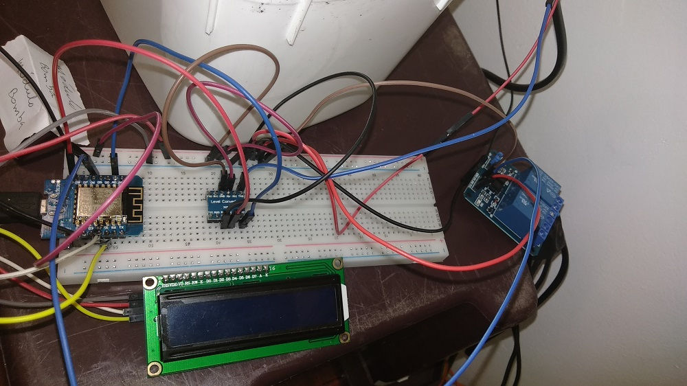

[figure not shown]

- *Sketch* **`Teste_11B_Bomba_Melhorado`**

## 4.2 - Módulo Irrigação:

[figure not shown]

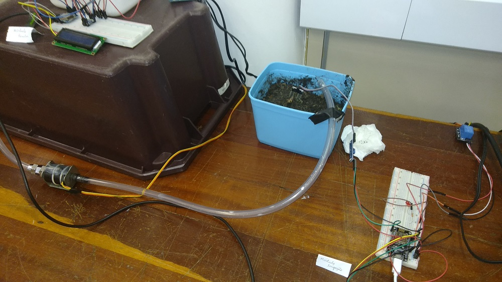